# trend_analysis_theil_sen

## Theil-Sen analysis

So now we can run the Theil-Sen trend analysis on the PM<sub>10</sub> and PM<sub>2.5</sub> datasets

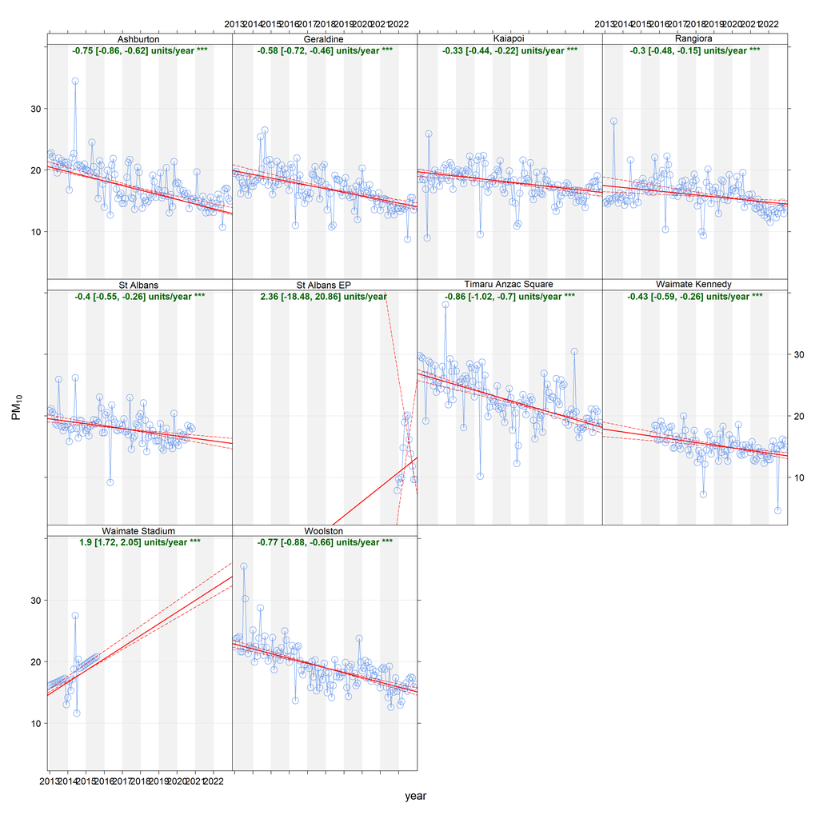

```r
# PM10 trend analysis
p_pm10 <- openair::TheilSen(
  df_daily_pm_clean,
  pollutant = "PM10",
  deseason = TRUE,
  date.format = "%Y",
  type = "site",
  data.thresh = 75,
  fontsize = 20
  )
```

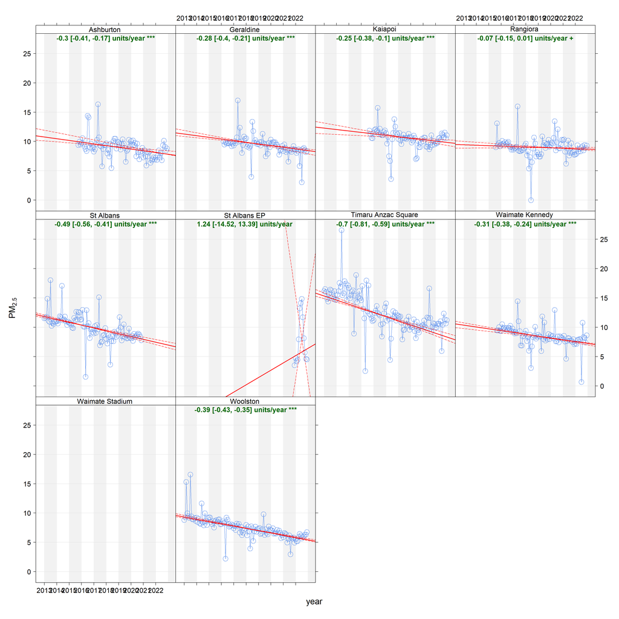

```r
# And TheilSen for PM2.5
p_pm25 <- openair::TheilSen(
  df_daily_pm_clean,
  pollutant = "PM25",
  deseason = TRUE,
  date.format = "%Y",
  type = "site",
  data.thresh = 75,
  fontsize = 20
  )
```

## Trend analysis using `.csv` file

We can also run the same analysis using data retrieved from a .csv file. This is handy for comparison.

**Note**

Note the dataset dates need to match if comparing .csv read and retrievals from the website

### Get the data

This assumes the data has been prepared in a .csv file which is included in this [GitHub](https://github.com/bws200/theil-sen-trend-analysis-ecan) repository under `/data`. It is for Environment Canterbury’s Rangiora site only. A larger .csv file could be created which includes site name as an additional column.

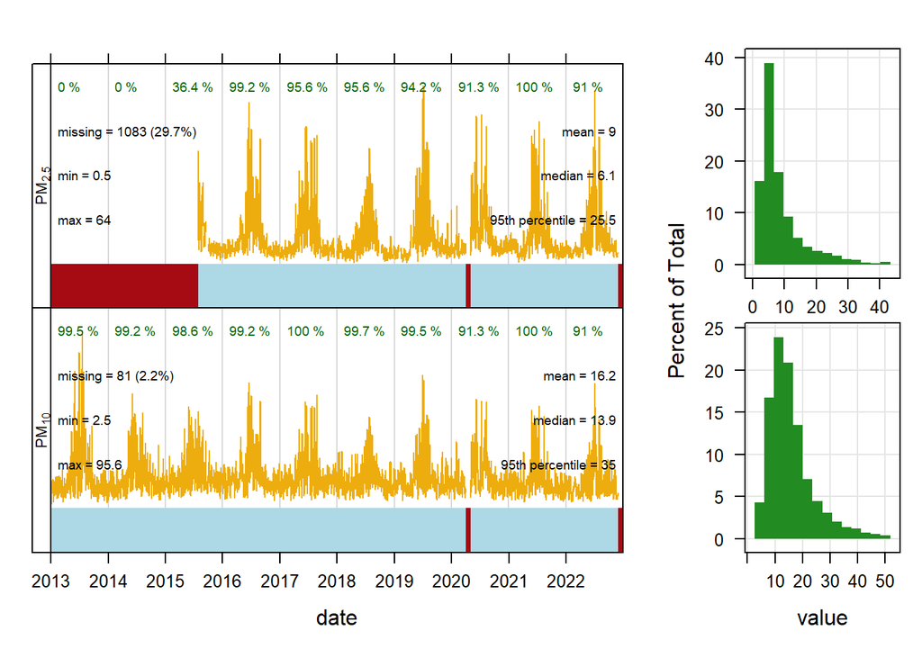

```r
# Read file
df_csv <- read.csv(
  file = "data/Rangiora PM10 2013 to 2022.csv"
) |>
  rename(
    date = DateTime,
    PM10 = PM10..ug.m3.,
    PM25 = PM2.5..ug.m3.
  ) |>
  mutate(date = lubridate::dmy(date))

df_csv |>
  # Add as.character to make data %'s work ok
  mutate(date = as.character(date)) |>
  openair::summaryPlot(
    pollutant = "PM10"
  )
```

**Note**

The `.csv` dataset is not complete for 2022

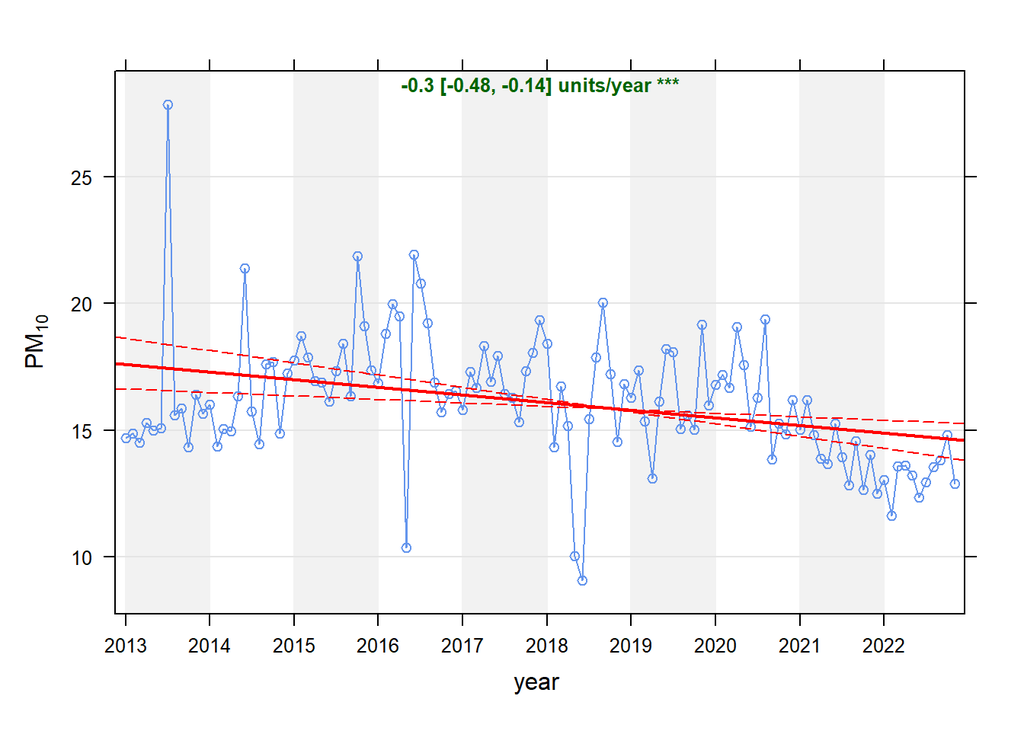

```r
# Run the trend analysis
openair::TheilSen(
  df_csv,
  pollutant = "PM10",
  deseason = TRUE,
  date.format = "%Y",
  data.thresh = 75
)
```